# p8105_hw5_anh2179

2026-11-16

## Problem 1

### Function

```r
bday_sim = function(n) {

  birthdays = sample(1:365, n, replace = TRUE)

  tibble(
    shared = as.numeric(length(unique(birthdays)) < n))
}
```

### Simulation

```r
bday_results_df =
  expand_grid(
    group_size = 2:50,
    iter = 1:10000) |>
  mutate(
    estimate_df = map(group_size, bday_sim)) |>
  unnest(estimate_df) |>
  group_by(group_size) |>
  summarize(prob_shared = mean(shared))
bday_results_df |>
  filter(group_size %in% c(10, 20, 23, 30, 40, 50)) |>
  knitr::kable(digits = 3)
```

| group_size | prob_shared |
| --- | --- |
| 10 | 0.116 |
| 20 | 0.412 |
| 23 | 0.502 |
| 30 | 0.705 |
| 40 | 0.888 |
| 50 | 0.972 |

### Plot

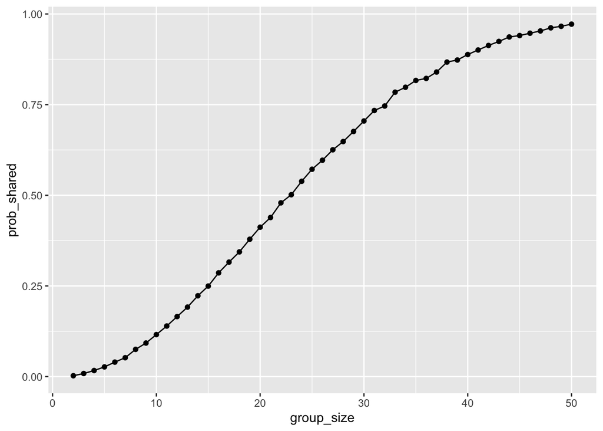

```r
bday_results_df |>
  ggplot(aes(x = group_size, y = prob_shared)) +
  geom_point() +
  geom_path()
```

The probability that at least two people share a birthday increases with group size, and the increase is not linear. With 5 people the probability is 0.0267. It first passes 0.5 at a group size of 23, and with 50 people it is 0.972. The curve climbs fastest at moderate group sizes and then levels off near 1. A shared birthday becomes likely in fairly small groups because the number of pairs of people grows much faster than the number of people.

## Problem 2

### Import

```r
full_df =
  tibble(
    files = list.files("data/"),
    path = str_c("data/", files)
  ) |>
  mutate(data = map(path, read_csv)) |>
  unnest(cols = data)
```

### Tidy

```r
tidy_df =
  full_df |>
  mutate(
    files = str_replace(files, ".csv", ""),
    arm = str_sub(files, 1, 3),
    arm = str_replace(arm, "con", "control"),
    arm = str_replace(arm, "exp", "experimental"),
    subject_id = str_sub(files, 5, 6)) |>
  pivot_longer(
    week_1:week_8,
    names_to = "week",
    values_to = "outcome",
    names_prefix = "week_") |>
  mutate(week = as.numeric(week)) |>
  select(arm, subject_id, week, outcome)
```

The tidy dataset has 160 rows and 4 columns: arm, subject_id, week, outcome. Each row is one subject’s outcome in one week. Subject IDs 01–10 are used in both arms, so a subject is identified by arm and subject ID together.

### Spaghetti plot

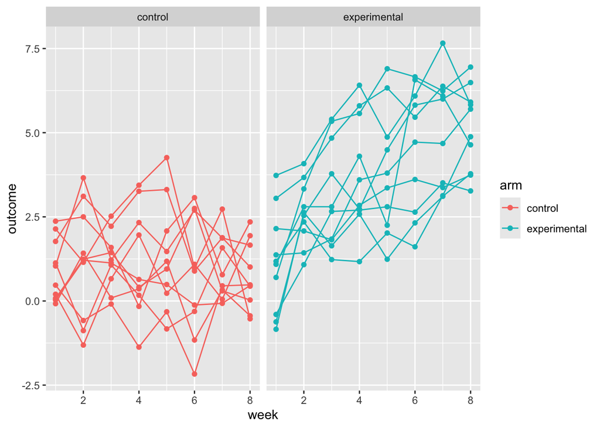

```r
tidy_df |>
  ggplot(aes(x = week, y = outcome, group = str_c(arm, subject_id), color = arm)) +
  geom_point() +
  geom_path() +
  facet_grid(~arm)
```

### Group means

```r
group_means_df =
  tidy_df |>
  filter(week %in% c(1, 8)) |>
  group_by(arm, week) |>
  summarize(mean_outcome = mean(outcome))
```

```
## `summarise()` has regrouped the output.
## ℹ Summaries were computed grouped by arm and week.
## ℹ Output is grouped by arm.
## ℹ Use `summarise(.groups = "drop_last")` to silence this message.
## ℹ Use `summarise(.by = c(arm, week))` for per-operation grouping
##   (`?dplyr::dplyr_by`) instead.
```

At week 1 the two groups look similar. The mean outcome is 0.92 in the control group and 1.14 in the experimental group. Over the 8 weeks, outcomes in the experimental group increase steadily, while the control group stays roughly flat. By week 8 the mean outcome is 0.74 for control and 5.12 for experimental, so most experimental subjects end above the control subjects.

## Problem 3

### Function

```r
sim_t_test = function(mu, n = 30, sigma = 5) {

  x = rnorm(n, mean = mu, sd = sigma)

  t.test(x, mu = 0) |>
    broom::tidy() |>
    select(mu_hat = estimate, p.value)
}
```

### Simulation

```r
sim_results_df =
  expand_grid(
    true_mu = 0:6,
    iter = 1:5000
  ) |>
  mutate(
    estimate_df = map(true_mu, sim_t_test)
  ) |>
  unnest(estimate_df) |>
  mutate(rejected = as.numeric(p.value < 0.05))
```

### Power

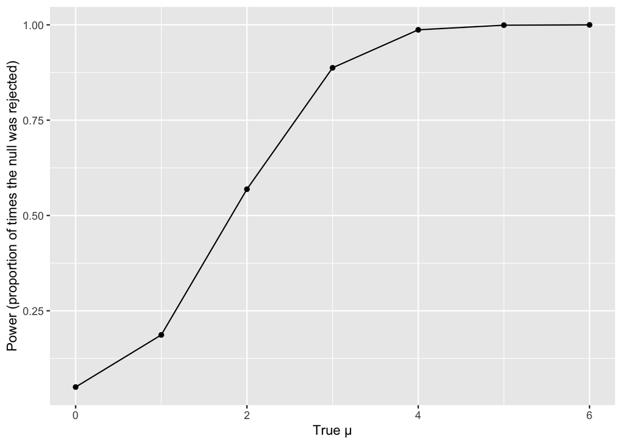

```r
power_df =
  sim_results_df |>
  group_by(true_mu) |>
  summarize(power = mean(rejected))

power_df |>
  ggplot(aes(x = true_mu, y = power)) +
  geom_point() +
  geom_path() +
  labs(
    x = "True μ",
    y = "Power (proportion of times the null was rejected)")
```

Power increases with effect size. When μ = 0 the null is true, and the null is rejected 0.05 of the time, close to α = 0.05. Power is 0.1868 at μ = 1, 0.569 at μ = 2 and 0.8874 at μ = 3, and it is close to 1 for μ = 5 and 6 (1 at μ = 6). With n and σ fixed, a larger true μ makes the difference from 0 easier to detect.

### Average estimates

```r
all_df =
  sim_results_df |>
  group_by(true_mu) |>
  summarize(avg_mu_hat = mean(mu_hat)) |>
  mutate(samples = "all")

rejected_df =
  sim_results_df |>
  filter(rejected == 1) |>
  group_by(true_mu) |>
  summarize(avg_mu_hat = mean(mu_hat)) |>
  mutate(samples = "rejected")

estimates_df = bind_rows(all_df, rejected_df)
```

### Estimates plot

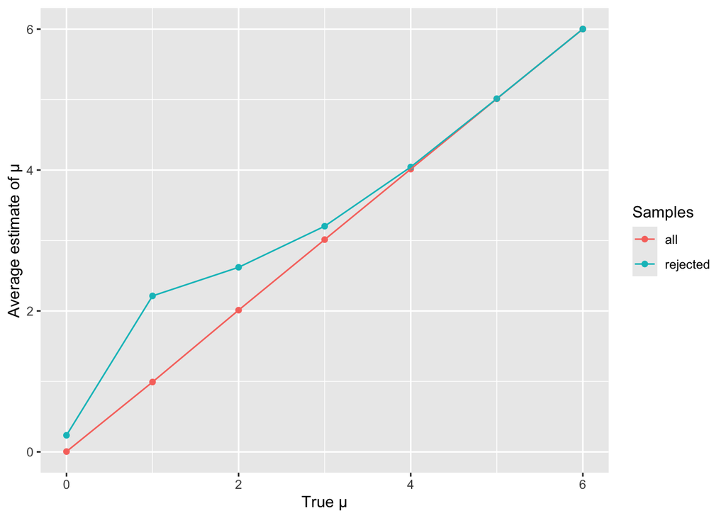

```r
estimates_df |>
  ggplot(aes(x = true_mu, y = avg_mu_hat, color = samples)) +
  geom_point() +
  geom_path() +
  labs(
    x = "True μ",
    y = "Average estimate of μ",
    color = "Samples")
```

### Comments

Across all samples, the average μ̂ is close to the true μ for every value; at μ = 1 it is 0.99. Across only the samples where the null was rejected, the average μ̂ is not equal to the true μ when power is low. At μ = 1 it is 2.21, and at μ = 2 it is 2.62. This happens because a sample only rejects the null when its μ̂ is far enough from 0. When the true effect is small, mostly the samples that overestimated μ get rejected, so their average is too high. As μ increases, power gets close to 1 and almost every sample is rejected. The rejected samples then make up nearly all of the samples, and their average gets close to the true μ; at μ = 6 it is 6.